# Biostat 212A Homework 3

Due Feb 20, 2024 @ 11:59PM

Author

Yuhui Wang, UID:606332401

Published

February 7, 2024

```r
library(ISLR2)
library(boot)
library(tidyverse)
library(MASS)
library(glmnet)
library(pls)
```

## 1 ISL Exercise 5.4.2 (10pts)

> We will now derive the probability that a given observation is part of a bootstrap sample. Suppose that we obtain a bootstrap sample from a set of n observations.
> 1. What is the probability that the first bootstrap observation is *not* the $j$th observation from the original sample? Justify your answer.

This is 1 - probability that it is the $j$th = $1 - 1/n$.

> 2. What is the probability that the second bootstrap observation is *not* the $j$th observation from the original sample?

Since each bootstrap observation is a random sample, this probability is the same ($1 - 1/n$).

> 3. Argue that the probability that the $j$th observation is *not* in the bootstrap sample is $(1 - 1/n)^n$.

For the $j$th observation to not be in the sample, it would have to *not* be picked for each of $n$ positions, so not picked for $1, 2, ..., n$, thus the probability is $(1 - 1/n)^n$

> 4. When $n = 5$, what is the probability that the $j$th observation is in the bootstrap sample?

```r
n <- 5
1 - (1 - 1 / n)^n
```

```
[1] 0.67232
```

$p = 0.67$

> 5. When $n = 100$, what is the probability that the $j$th observation is in the bootstrap sample?

```r
n <- 100
1 - (1 - 1 / n)^n
```

```
[1] 0.6339677
```

> 6. When $n = 10,000$, what is the probability that the $j$th observation is in the bootstrap sample?

```r
n <- 100000
1 - (1 - 1 / n)^n
```

```
[1] 0.6321224
```

$p = 0.63$

> 7. Create a plot that displays, for each integer value of $n$ from 1 to 100,000, the probability that the $j$th observation is in the bootstrap sample. Comment on what you observe.

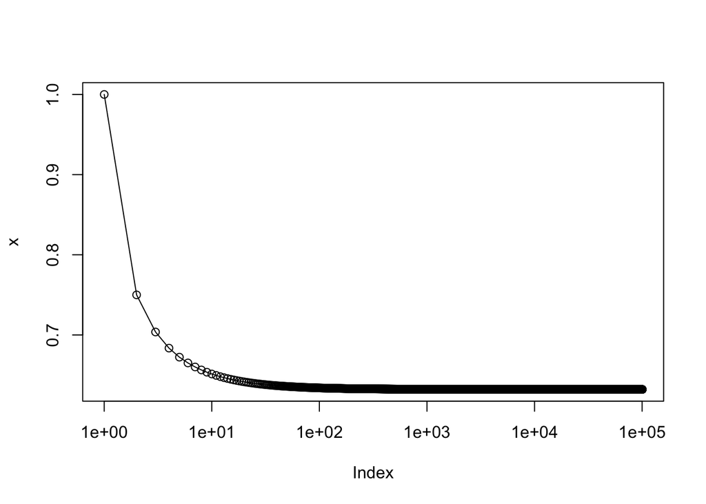

```r
x <- sapply(1:100000, function(n) 1 - (1 - 1 / n)^n)
plot(x, log = "x", type = "o")
```

The probability rapidly approaches 0.63 with increasing $n$.

Note that
$$e^x = \lim_{x \to \inf} \left(1 + \frac{x}{n}\right)^n,$$
so with $x = -1$, we can see that our limit is $1 - e^{-1} = 1 - 1/e$.

> 8. We will now investigate numerically the probability that a bootstrap sample of size $n = 100$ contains the $j$th observation. Here $j = 4$. We repeatedly create bootstrap samples, and each time we record whether or not the fourth observation is contained in the bootstrap sample.

>    ```r
>    > store <- rep (NA, 10000)
>    > for (i in 1:10000) {
>        store[i] <- sum(sample(1:100, rep = TRUE) == 4) > 0
>    }
>    > mean(store)
>    ```

>    Comment on the results obtained.

```r
store <- replicate(10000, sum(sample(1:100, replace = TRUE) == 4) > 0)
mean(store)
```

```
[1] 0.6266
```

The probability of including $4$ when resampling numbers $1...100$ is close to $1 - (1 - 1/100)^{100}$.

## 2 ISL Exercise 5.4.9 (20pts)

> We will now consider the `Boston` housing data set, from the `ISLR2` library.
> 1. Based on this data set, provide an estimate for the population mean of `medv`. Call this estimate $\hat\mu$.

```r
(mu <- mean(Boston$medv))
```

```
[1] 22.53281
```

> 2. Provide an estimate of the standard error of $\hat\mu$. Interpret this result.

> *Hint: We can compute the standard error of the sample mean by dividing the sample standard deviation by the square root of the number of observations.*

```r
sd(Boston$medv) / sqrt(length(Boston$medv))
```

```
[1] 0.4088611
```

> 3. Now estimate the standard error of $\hat\mu$ using the bootstrap. How does this compare to your answer from (b)?

```r
set.seed(42)
(bs <- boot(Boston$medv, function(v, i) mean(v[i]), 10000))
```

```
ORDINARY NONPARAMETRIC BOOTSTRAP


Call:
boot(data = Boston$medv, statistic = function(v, i) mean(v[i]),
    R = 10000)


Bootstrap Statistics :
    original      bias    std. error
t1* 22.53281 0.002175751   0.4029139
```

The standard error using the bootstrap (0.403) is very close to that obtained from the formula above (0.409).

> 4. Based on your bootstrap estimate from (c), provide a 95% confidence interval for the mean of `medv`. Compare it to the results obtained using `t.test(Boston$medv)`.

> *Hint: You can approximate a 95% confidence interval using the formula $[\hat\mu - 2SE(\hat\mu), \hat\mu + 2SE(\hat\mu)].$*

```r
se <- sd(bs$t)
c(mu - 2 * se, mu + 2 * se)
```

```
[1] 21.72698 23.33863
```

> 5. Based on this data set, provide an estimate, $\hat\mu_{med}$, for the median value of `medv` in the population.

```r
median(Boston$medv)
```

```
[1] 21.2
```

> 6. We now would like to estimate the standard error of $\hat\mu_{med}$. Unfortunately, there is no simple formula for computing the standard error of the median. Instead, estimate the standard error of the median using the bootstrap. Comment on your findings.

```r
set.seed(42)
boot(Boston$medv, function(v, i) median(v[i]), 10000)
```

```
ORDINARY NONPARAMETRIC BOOTSTRAP


Call:
boot(data = Boston$medv, statistic = function(v, i) median(v[i]),
    R = 10000)


Bootstrap Statistics :
    original   bias    std. error
t1*     21.2 -0.01331   0.3744634
```

The estimated standard error of the median is 0.374. This is lower than the standard error of the mean.

> 7. Based on this data set, provide an estimate for the tenth percentile of `medv` in Boston census tracts. Call this quantity $\hat\mu_{0.1}$. (You can use the `quantile()` function.)

```r
quantile(Boston$medv, 0.1)
```

```
  10%
12.75
```

> 8. Use the bootstrap to estimate the standard error of $\hat\mu_{0.1}$. Comment on your findings.

```r
set.seed(42)
boot(Boston$medv, function(v, i) quantile(v[i], 0.1), 10000)
```

```
ORDINARY NONPARAMETRIC BOOTSTRAP


Call:
boot(data = Boston$medv, statistic = function(v, i) quantile(v[i],
    0.1), R = 10000)


Bootstrap Statistics :
    original   bias    std. error
t1*    12.75 0.013405    0.497298
```

We get a standard error of ~0.5. This is higher than the standard error of the median. Nevertheless the standard error is quite small, thus we can be fairly confidence about the value of the 10th percentile.

## 3 Least squares is MLE (10pts)

Show that in the case of linear model with Gaussian errors, maximum likelihood and least squares are the same thing, and $C_p$ and AIC are equivalent.

## 4 ISL Exercise 6.6.1 (10pts)

> We perform best subset, forward stepwise, and backward stepwise selection on a single data set. For each approach, we obtain $p + 1$ models, containing $0, 1, 2, ..., p$ predictors. Explain your answers:
> 1. Which of the three models with $k$ predictors has the smallest *training* RSS?

Best subset considers the most models (all possible combinations of $p$ predictors are considered), therefore this will give the smallest training RSS (it will at least consider all possibilities covered by forward and backward stepwise selection). However, all three approaches are expected to give similar if not identical results in practice.

> 2. Which of the three models with $k$ predictors has the smallest *test* RSS?

We cannot tell which model will perform best on the test RSS. The answer will depend on the tradeoff between fitting to the data and overfitting.

> 3. True or False:
>    1. The predictors in the $k$-variable model identified by forward stepwise are a subset of the predictors in the ($k+1$)-variable model identified by forward stepwise selection.

True. Forward stepwise selection retains all features identified in previous models as $k$ is increased.

> 2. The predictors in the $k$-variable model identified by backward stepwise are a subset of the predictors in the $(k+1)$-variable model identified by backward stepwise selection.

True. Backward stepwise selection removes features one by one as $k$ is decreased.

> 3. The predictors in the $k$-variable model identified by backward stepwise are a subset of the predictors in the $(k+1)$-variable model identified by forward stepwise selection.

False. Forward and backward stepwise selection can identify different combinations of variables due to differing algorithms.

> 4. The predictors in the $k$-variable model identified by forward stepwise are a subset of the predictors in the $(k+1)$-variable model identified by backward stepwise selection.

False. Forward and backward stepwise selection can identify different combinations of variables due to differing algorithms.

> 22. The predictors in the $k$-variable model identified by best subset are a subset of the predictors in the $(k+1)$-variable model identified by best subset selection.

False. Best subset selection can identify different combinations of variables for each $k$ by considering all possible models.

## 5 ISL Exercise 6.6.3 (10pts)

> Suppose we estimate the regression coefficients in a linear regression model by minimizing:

> $$\sum_{i=1}^n\left(y_i - \beta_0 - \sum_{j=1}^p\beta_jx_{ij}\right)^2
> \textrm{subject to} \sum_{j=1}^p|\beta_j| \le s$$

> for a particular value of $s$. For parts (a) through (e), indicate which of i. through v. is correct. Justify your answer.
> 1. As we increase $s$ from 0, the training RSS will:
>    1. Increase initially, and then eventually start decreasing in an inverted U shape.
>    2. Decrease initially, and then eventually start increasing in a U shape.
>    3. Steadily increase.
>    4. Steadily decrease.
>    5. Remain constant.
4. As $s$ increases, the model becomes more flexible (the sum of absolute coefficients can be higher). With more flexible models, training RSS will always decrease.
> 2. Repeat (a) for test RSS.
2. With more flexible models, test RSS will decrease (as the fit improves) and will then increase due to overfitting (high variance).
> 3. Repeat (a) for variance.
3. As $s$ increases, the model becomes more flexible so variance will increase.
> 4. Repeat (a) for (squared) bias.
4. As $s$ increases, the model becomes more flexible so bias will decrease.
> 5. Repeat (a) for the irreducible error.
22. The irreducible error is unchanged.

## 6 ISL Exercise 6.6.4 (10pts)

> Suppose we estimate the regression coefficients in a linear regression model by minimizing

> $$\sum_{i=1}^n \left(y_i - \beta_0 - \sum_{j=1}^p\beta_jx_{ij}\right)^2 +
> \lambda\sum_{j=1}^p\beta_j^2$$

> for a particular value of $\lambda$. For parts (a) through (e), indicate which of i. through v. is correct. Justify your answer.
> 1. As we increase $\lambda$ from 0, the training RSS will:
>    1. Increase initially, and then eventually start decreasing in an inverted U shape.
>    2. Decrease initially, and then eventually start increasing in a U shape.
>    3. Steadily increase.
>    4. Steadily decrease.
>    5. Remain constant.
3. As $\lambda$ is increased, more weight is placed on the sum of squared coefficients and so the model becomes less flexible. As a result, training RSS must increase.
> 2. Repeat (a) for test RSS.
2. As $\lambda$ increases, flexibility decreases so test RSS will decrease (variance decreases) but will then increase (as bias increases).
> 3. Repeat (a) for variance.
4. Steadily decrease.
> 4. Repeat (a) for (squared) bias.
3. Steadily increase.
> 5. Repeat (a) for the irreducible error.
22. The irreducible error is unchanged.

## 7 ISL Exercise 6.6.5 (10pts)

> It is well-known that ridge regression tends to give similar coefficient values to correlated variables, whereas the lasso may give quite different coefficient values to correlated variables. We will now explore this property in a very simple setting.

> Suppose that $n = 2, p = 2, x_{11} = x_{12}, x_{21} = x_{22}$. Furthermore, suppose that $y_1 + y_2 =0$ and $x_{11} + x_{21} = 0$ and $x_{12} + x_{22} = 0$, so that the estimate for the intercept in a least squares, ridge regression, or lasso model is zero: $\hat{\beta}_0 = 0$.
> 1. Write out the ridge regression optimization problem in this setting.

We are trying to minimize:

$$\sum_{i=1}^n \left(y_i - \beta_0 - \sum_{j=1}^p\beta_jx_{ij}\right)^2 +
\lambda\sum_{j=1}^p\beta_j^2$$

We can ignore $\beta_0$ and can expand the sums since there’s only two terms. Additionally, we can define $x_1 = x_{11} = x_{12}$ and $x_2 = x_{21} = x_{22}$. We then need to minimize

$$\begin{align}
f = & (y_1 - \beta_1x_1 - \beta_2x_1)^2 +
(y_2 - \beta_1x_2 - \beta_2x_2)^2 +
\lambda\beta_1^2 + \lambda\beta_2^2 \\
f = & y_1^2 - 2y_1\beta_1x_1 - 2y_1\beta_2x_1 + \beta_1^2x_1^2 + 2\beta_1\beta_2x_1^2 + \beta_2^2x_1^2 + \\
& y_2^2 - 2y_2\beta_1x_2 - 2y_2\beta_2x_2 + \beta_1^2x_2^2 + 2\beta_1\beta_2x_2^2 + \beta_2^2x_2^2 + \\
& \lambda\beta_1^2 + \lambda\beta_2^2 \\
\end{align}$$

> 2. Argue that in this setting, the ridge coefficient estimates satisfy $\hat{\beta}_1 = \hat{\beta}_2$

We can find when the above is minimized with respect to each of $\beta_1$ and $\beta_2$ by partial differentiation.

$$\frac{\partial}{\partial{\beta_1}} =
- 2y_1x_1 + 2\beta_1x_1^2 + 2\beta_2x_1^2
- 2y_2x_2 + 2\beta_1x_2^2 + 2\beta_2x_2^2
+ 2\lambda\beta_1$$

$$\frac{\partial}{\partial{\beta_2}} =
- 2y_1x_1 + 2\beta_1x_1^2 + 2\beta_2x_1^2
- 2y_2x_2 + 2\beta_1x_2^2 + 2\beta_2x_2^2
+ 2\lambda\beta_2$$

A minimum can be found when these are set to 0.

$$\lambda\beta_1 = y_1x_1 + y_2x_2 - \beta_1x_1^2 - \beta_2x_1^2 - \beta_1x_2^2 - \beta_2x_2^2 \\
\lambda\beta_2 = y_1x_1 + y_2x_2 - \beta_1x_1^2 - \beta_2x_1^2 - \beta_1x_2^2 - \beta_2x_2^2$$

Therefore $\lambda\beta_1 = \lambda\beta_2$ and $\beta_1 = \beta_2$, thus there is only one solution, that is when the coefficients are the same.

> 3. Write out the lasso optimization problem in this setting.

We are trying to minimize:

$$\sum_{i=1}^n \left(y_i - \beta_0 - \sum_{j=1}^p\beta_jx_{ij}\right)^2 +
\lambda\sum_{j=1}^p |\beta_j|$$

As above (and defining $x_1 = x_{11} = x_{12}$ and $x_2 = x_{21} = x_{22}$) we simplify to

$$(y_1 - \beta_1x_1 - \beta_2x_1)^2 +
(y_2 - \beta_1x_2 - \beta_2x_2)^2 +
\lambda|\beta_1| + \lambda|\beta_2|$$

> 4. Argue that in this setting, the lasso coefficients $\hat{\beta}_1$ and $\hat{\beta}_2$ are not unique—in other words, there are many possible solutions to the optimization problem in (c). Describe these solutions.

We will consider the alternate form of the lasso optimization problem

$$(y_1 - \hat{\beta_1}x_1 - \hat{\beta_2}x_1)^2 + (y_2 - \hat{\beta_1}x_2 - \hat{\beta_2}x_2)^2 \quad \text{subject to} \quad |\hat{\beta_1}| + |\hat{\beta_2}| \le s$$

Since $x_1 + x_2 = 0$ and $y_1 + y_2 = 0$, this is equivalent to minimising $2(y_1 - (\hat{\beta_1} + \hat{\beta_2})x_1)^2$ which has a solution when $\hat{\beta_1} + \hat{\beta_2} = y_1/x_1$. Geometrically, this is a $45^\circ$ backwards sloping line in the ($\hat{\beta_1}$, $\hat{\beta_2}$) plane.

The constraints $|\hat{\beta_1}| + |\hat{\beta_2}| \le s$ specify a diamond shape in the same place, also with lines that are at $45^\circ$ centered at the origin and which intersect the axes at a distance $s$ from the origin.

Thus, points along two edges of the diamond ($\hat{\beta_1} + \hat{\beta_2} = s$ and $\hat{\beta_1} + \hat{\beta_2} = -s$) become solutions to the lasso optimization problem.

## 8 ISL Exercise 6.6.11 (30pts)

You must follow the [typical machine learning paradigm](https://ucla-econ-425t.github.io/2023winter/slides/06-modelselection/workflow_lasso.html) to compare *at least* 3 methods: least squares, lasso, and ridge. Report final results as

| Method | CV RMSE | Test RMSE |  |
| --- | --- | --- | --- |
| LS |  |  |  |
| Ridge |  |  |  |
| Lasso |  |  |  |
| … |  |  |  |

> We will now try to predict per capita crime rate in the `Boston` data set.
> 1. Try out some of the regression methods explored in this chapter, such as best subset selection, the lasso, ridge regression, and PCR. Present and discuss results for the approaches that you consider.

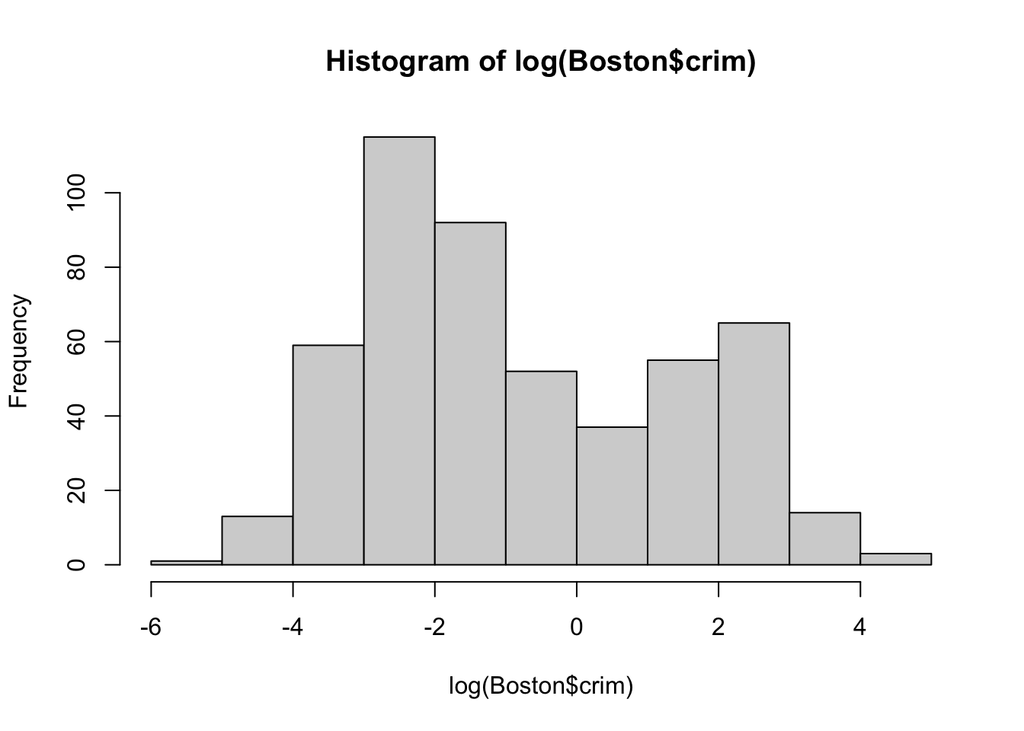

```r
set.seed(1)
train <- sample(nrow(Boston), nrow(Boston) * 2 / 3)
test <- setdiff(seq_len(nrow(Boston)), train)
hist(log(Boston$crim))
```

> 2. Propose a model (or set of models) that seem to perform well on this data set, and justify your answer. Make sure that you are evaluating model performance using validation set error, cross-validation, or some other reasonable alternative, as opposed to using training error.

We will try to fit models to `log(Boston$crim)` which is closer to a normal distribution.

```r
fit <- lm(log(crim) ~ ., data = Boston[train, ])
mean((predict(fit, Boston[test, ]) - log(Boston$crim[test]))^2)
```

```
[1] 0.6779016
```

```r
mm <- model.matrix(log(crim) ~ ., data = Boston[train, ])
fit2 <- cv.glmnet(mm, log(Boston$crim[train]), alpha = 0)
p <- predict(fit2, model.matrix(log(crim) ~ ., data = Boston[test, ]), s = fit2$lambda.min)
mean((p - log(Boston$crim[test]))^2)
```

```
[1] 0.665665
```

```r
mm <- model.matrix(log(crim) ~ ., data = Boston[train, ])
fit3 <- cv.glmnet(mm, log(Boston$crim[train]), alpha = 1)
p <- predict(fit3, model.matrix(log(crim) ~ ., data = Boston[test, ]), s = fit3$lambda.min)
mean((p - log(Boston$crim[test]))^2)
```

```
[1] 0.6541562
```

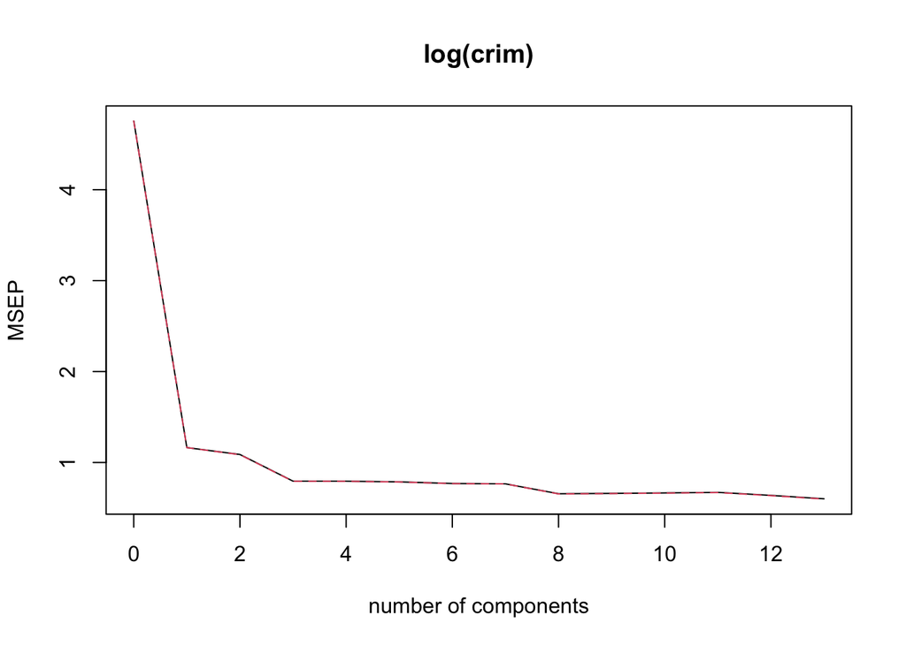

```r
fit4 <- pcr(log(crim) ~ ., data = Boston[train, ], scale = TRUE, validation = "CV")
validationplot(fit4, val.type = "MSEP")
```

```r
p <- predict(fit4, Boston[test, ], ncomp = 8)
mean((p - log(Boston$crim[test]))^2)
```

```
[1] 0.6609357
```

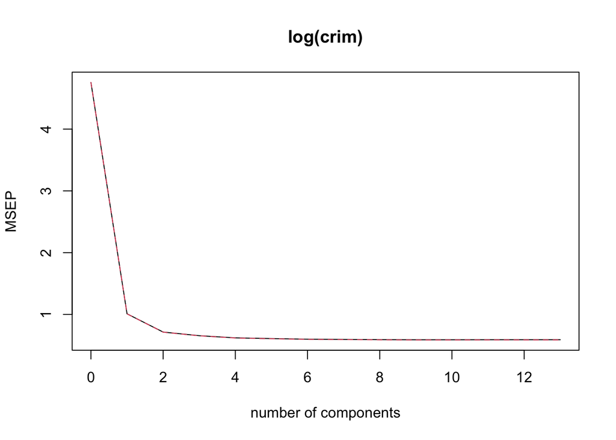

```r
fit5 <- plsr(log(crim) ~ ., data = Boston[train, ], scale = TRUE, validation = "CV")
validationplot(fit5, val.type = "MSEP")
```

```r
p <- predict(fit5, Boston[test, ], ncomp = 6)
mean((p - log(Boston$crim[test]))^2)
```

```
[1] 0.6911389
```

In this case lasso (`alpha = 1`) seems to perform very slightly better than un-penalized regression. Some coefficients have been dropped:

```r
coef(fit3, s = fit3$lambda.min)
```

```
15 x 1 sparse Matrix of class "dgCMatrix"
                      s1
(Intercept) -4.029305640
(Intercept)  .
zn          -0.011299858
indus        0.022032467
chas         .
nox          3.766724465
rm          -0.025289189
age          0.004397170
dis          .
rad          0.139103776
tax          .
ptratio     -0.026355504
black       -0.001732709
lstat        0.034798406
medv         0.009282387
```

> 3. Does your chosen model involve all of the features in the data set? Why or why not?

Not all features are included due to the lasso penalization.

## 9 Bonus question (20pts)

Consider a linear regression, fit by least squares to a set of training data $(x_1, y_1), \ldots, (x_N, y_N)$ drawn at random from a population. Let $\hat \beta$ be the least squares estimate. Suppose we have some test data $(\tilde{x}_1, \tilde{y}_1), \ldots, (\tilde{x}_M, \tilde{y}_M)$ drawn at random from the same population as the training data. If $R_{\text{train}}(\beta) = \frac{1}{N} \sum_{i=1}^N (y_i - \beta^T x_i)^2$ and $R_{\text{test}}(\beta) = \frac{1}{M} \sum_{i=1}^M (\tilde{y}_i - \beta^T \tilde{x}_i)^2$. Show that
$$\operatorname{E}[R_{\text{train}}(\hat{\beta})] < \operatorname{E}[R_{\text{test}}(\hat{\beta})].$$